# Final Project of Traffic Announcements (Istanbul-UYM)

Group A.K.A - R

12/27/2020

## Traffic Announcements of Istanbul (2018 - 2020)

The group analyzed, traffic announcements entered into the system from January 2018 to October 2020 by the transportation management center of İstanbul Municipality. In dataset there are 12 variables such as; Announcement Type, Starting and ending time of the event, Location, etc. and 58,422 records. The aim of the group was to conduct various analyzes using these 12 variables either individually or together.

[Click here for the Project Data](https://github.com/pjournal/mef04g-a-k-a-r/blob/gh-pages/Project_Datasets/data.RData)

[Click here for the Project Proposal](https://pjournal.github.io/mef04g-a-k-a-r/Project-Proposal.html)

[Click here for the Project EDA PDF](https://pjournal.github.io/mef04g-a-k-a-r/EDA-of-Traffic-Announcements--Istanbul-UYM-_PDF.pdf)

### Key Takeaways

At the end of the study, the group A.K.A - R observed the following takeaways;

### Analysis 1

- The traffic is assumed to be caused by two variables in our data set. These are, number of lanes affected from the incident and the duration of it. So “Problem Index” is created from multiplication of these variables.
- The outliers were detected with statistical methods. Records that were 3 standard deviations away from the mean is excluded from the data set. Approximately %99 confidence interval is created. Data is grouped by announcement type. Summarized and sorted according to the problem index.

*Date-related recording errors are filtered out from the subset because of the calculations.*

```
##            Announcement_Types Avg_Problem_Index CountAnnouncement SumIndex
## 5         Infrastructure Work        90.6383582                67  6072.77
## 4      Construction Work-Road        59.9131707                41  2456.44
## 6 Construction Work-Structure        26.4447059                17   449.56
## 2                 Maintenance        11.8293100              5290 62577.05
## 3                 Landscaping         5.1812475               505  2616.53
## 1       Accident Notification         0.9064472             26250 23794.24
```

The distribution of the announcement types regarding to the average problem index, are shown on the pie chart.

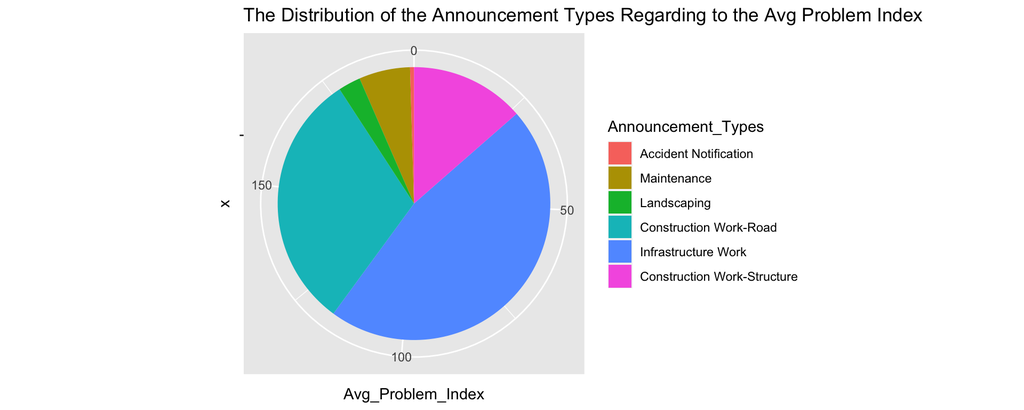

- It is shown that infrastructural or road constructional incidences were the worst traffic makers on average. However, car accidents and maintenance works occurred more frequently.Therefore, when it was summed up, these were the main traffic generators in total.

TOP 5 locations regarding problem index:

```
##                                             Location Problem_Index
## 11553                   S.Yolu Z.Burnu-Bakırköy yönü      23801.00
## 1347    Tünel Vecdi Diker Altunizade - Ümraniye yönü      18630.00
## 5030                        D100 Kınalı-Silivri Yönü      13202.00
## 6734  D100 Kadıköy-Çamlıca D100 Çamlıca-Kadıköy Yönü      13069.77
## 3687         Şile Yolu Tepeüstü-Ümraniye Kavşak Yönü      10921.15
```

[interactive chart not shown]

### Analysis 2

- It is examined whether there is a relationship between the municipality elections and the number of running projects/constructions etc.

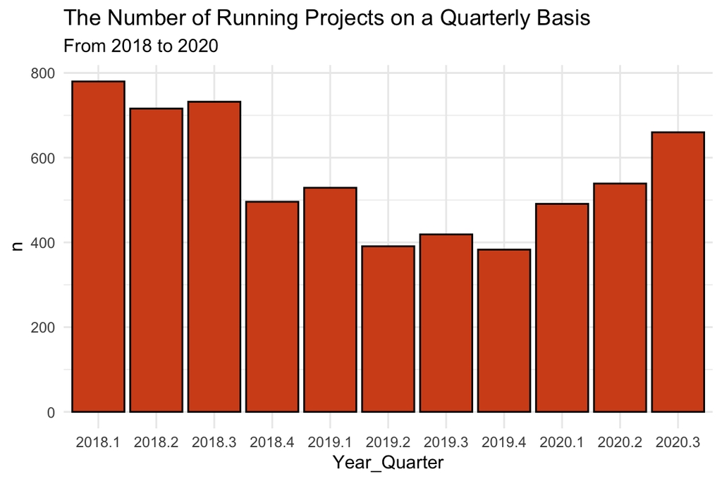

*Since the November of 2020 is not completed yet, is not included in the study and date-related recording errors are kept on the subset.*

### Analysis 3

- It is investigated whether there is an effect of the pandemic on the number of Accidents.

The number of Accidents are shown on the bar chart on a year-month basis. The bar chart has been colored on an annual basis for a clear view.

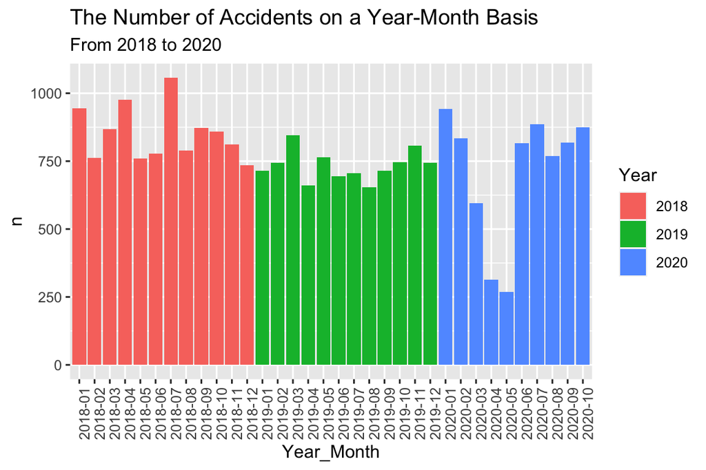

*Since the November of 2020 is not completed yet, is not included in the study and date-related recording errors are kept on the subset.*

- There is a clear effect of the pandemic that can be seen in 2020. The first pandemic case occurred in March in Turkey. In April and May, there were a lot of lockdowns were applied. The number of Accidents significantly decreased in that period. After rule bendings and starting of the summer period, the numbers increased again.
- Besides, there is a peak on 2018-07 that is seen on the chart. To investigate in more detail, the daily number of the Accidents in 2018-07 is plotted.

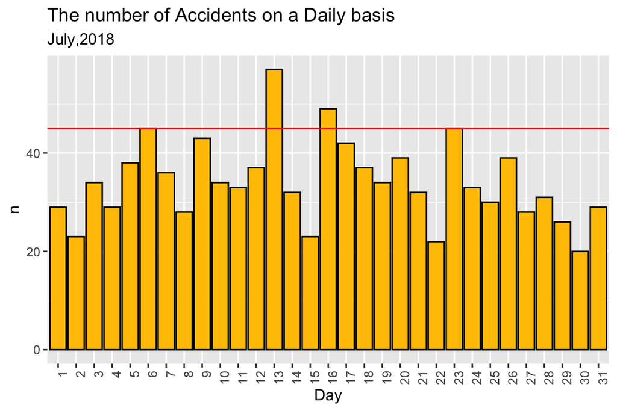

- 13th and 16th of July had the highest number of Accidents. 15’th of July is a national holiday in Turkey. 15’th of July was Sunday so the increase of these days could be because of that people tend to combine holidays and travel more before and after national holidays.

### Analysis 4

- Relationship between official holiday and traffic announcements are examined.
- Official holiday events are introduced to the data set in order to define holiday periods in the data. For instance, ‘New Year’, ‘Labor Day’, ‘Ramadan’, ‘National Sovereignty and Children’s Day’ and ‘May 19 Commemoration of Atatürk and Youth and Sports Day’.
- In the data set, weeks that are includes any of the holiday event are taken into consideration.
- Announcements that are reported during the holiday week are counted. Then, total number of announcements are shown on the pie chart in order to interpret the most common announcement reasons in the holiday term.

The distribution of Announcement Types during holiday weeks are shown in the below pie chart.

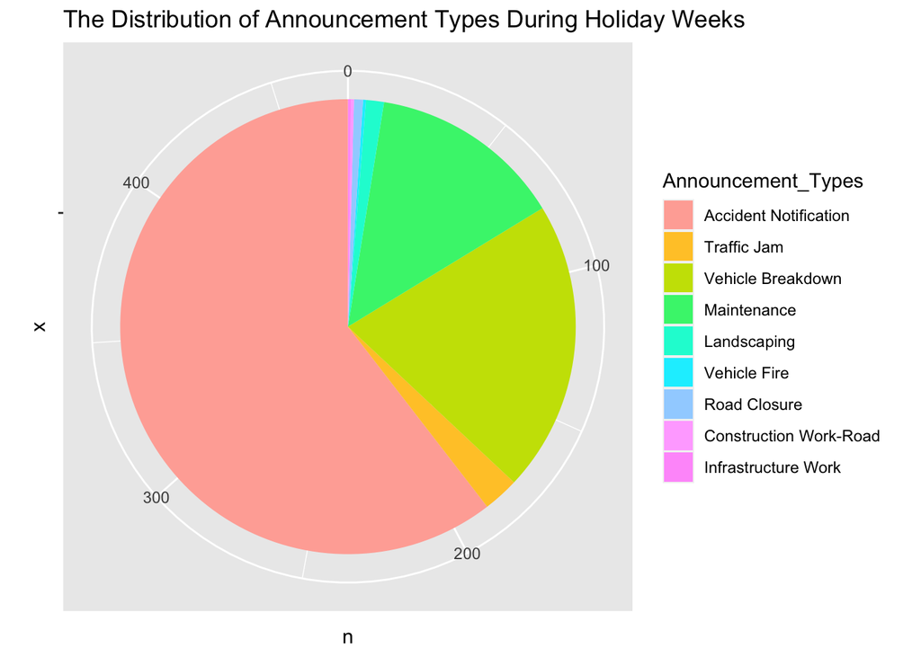

*The external data source is added for holiday events.*

*Date-related recording errors are kept on the subset.*

- In the holiday periods, majority of traffic announcements are occurred by the accident notification records. Presumably, increased intercity travels are caused to accidents during holiday week.
- Similarly, vehicle breakdown is affected by heavy travel demand and has got the second highest percentage among announcement types.
- Remarkable results belong to the number of Maintenance. Municipality may prefer to complete road works when the city is relatively empty because traffic on the road will be less than the regular term. Under this circumstances, working on road maintenance will be more productive.

### References

- [Data Source - İBB Open Data Portal](https://data.ibb.gov.tr/dataset/ulasim-yonetim-merkezi-uym-tarafindan-sisteme-girilen-trafik-duyurulari)
- [External Data Source - Holiday Events](https://www.tatilsepeti.com/resmi-tatil-gunleri)
- [Mapping Link](https://medium.com/@joyplumeri/how-to-make-interactive-maps-in-r-shiny-brief-tutorial-c2e1ef0447da)

*You may click* [here](https://pjournal.github.io/mef04g-a-k-a-r/) *to reach other items of A.K.A - R Group’s Progress Journal.*